# Heritability-02.md

Garett Slater

April 21 2022

```r
# Display the current working directory
getwd();
```

```
[1] "/Users/garettslater/OneDrive/Manuscripts/GenesOfDrones/Code/Github_GenesofDrones_Final"
```

```r
library(pacman)
p_load(readxl,dplyr,tidyverse,lme4,nadiv,MCMCglmm,QGglmm)


#Upload Trait Files
Sperm<-read_excel("~/OneDrive/Manuscripts/GenesOfDrones/Resources/Expression_Drone_Trait.xlsx",sheet="Sperm")
Weight<-read_excel("~/OneDrive/Manuscripts/GenesOfDrones/Resources/Expression_Drone_Trait.xlsx",sheet="Weight")
Morpho<-read_excel("~/OneDrive/Manuscripts/GenesOfDrones/Resources/Expression_Drone_Trait.xlsx",sheet="Morpho")
ID<-read_excel("~/OneDrive/Manuscripts/GenesOfDrones/Resources/Expression_Drone_Trait.xlsx",sheet="ID")
RFID_out<-read.csv("~/OneDrive/Manuscripts/GenesOfDrones/Resources/RFID_2020Final_out.csv")

ID<-ID%>%dplyr::filter(ID!="Texas" & ID!="Russian"& ID!="Purdue"& ID!="CAC"& ID!=0)
RFID_out<-merge(RFID_out,ID,by="UID")
RFID_out$UTCTime_Final<- with(RFID_out, as.POSIXct(paste(UTCDate, UTCTime), format="%m/%d/%Y %H:%M:%OS"))
var_out<-RFID_out %>% group_by(UID) %>% dplyr::summarise(N_flights=length(flight),mean_flight_timediff=mean(timediff)/60,first_flight_age=min(Drone_Age))
Sperm_1<-merge(Sperm,ID)
```

# Data Description

## Input Files

There are three input files that correspond to sperm, flight, and morphometric traits

Sperm Input File:

- Sperm_Conc_2: Sperm concentration (10^6)
- Sperm_viability: Viable sperm (%)

```
    Sperm_Conc_2 Sperm_viability Age  Colony    Line
1        7.78228      0.94071146  10 CAC2008      CA
2        0.68441      0.53932584  10 CAC2002      CA
3        1.04584      0.49264706  10 CAC2008      CA
4        1.66104      0.80092593  10 CAC2008      CA
5        5.39838      0.97008547  10 CAC2002      CA
6        4.73704      0.95129870  10 CAC2002      CA
```

Morphometric Input File: (Age is a factor)

```
        Weight    head_length head_width hindwing_length  hindwing_width  frontwing_length  frontwing_width
    1    0.19       3.640      1.761           7.543          3.204           11.997           3.829
    2    0.21       3.886      1.938           8.278          3.234           12.666           4.033
    3    0.23       3.955      1.765           8.141          3.364           12.489           4.058
    4    0.23       3.963      1.877           8.470          3.438           12.361           3.923
    5    0.22       4.039      1.590           8.269          3.007           12.273           3.827
    6    0.21       3.669      1.952           8.182          3.267           12.233           3.851
```

Flight Input File: (Age is a factor)

```
         N_flights    mean_flight_timediff  first_flight_age   Colony            Age
1          17          21.38137255                6             R2005            20
2          10          17.23166667                8             CAI2004          14
3          12          55.58194444                7             TX2001           20
4          15          20.68666667                3             R2005            14
5           6          40.16666667                8             CAC2007          14
6           1           0.20000000                8             CAI2004          10
```

# 1. Generate distribution for each trait

I began by generating distributions for each trait.

## Flight Traits

I looked at distribution of three flight traits:

Flight traits regardless of age.

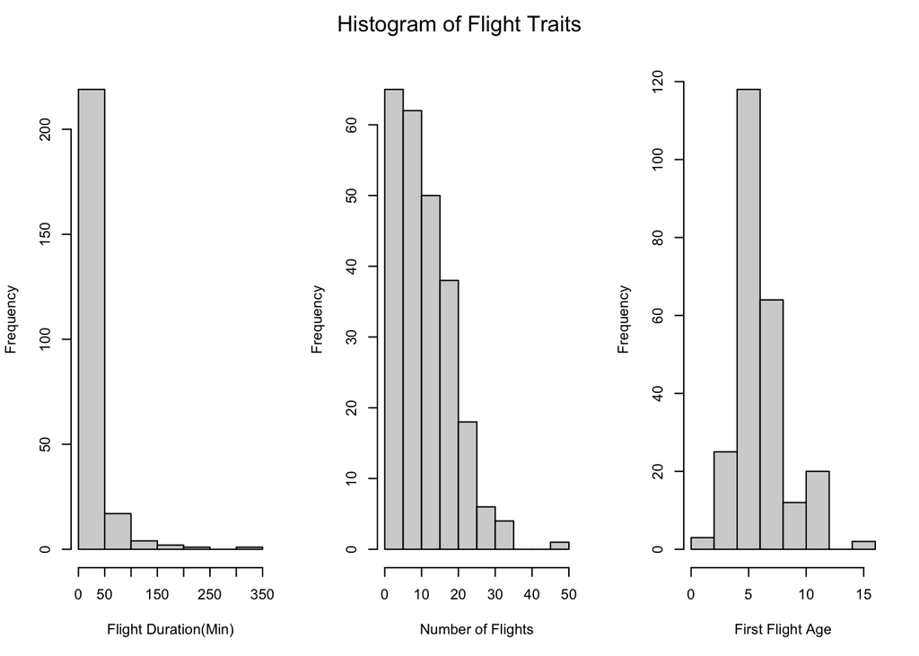

Flight traits for age 10

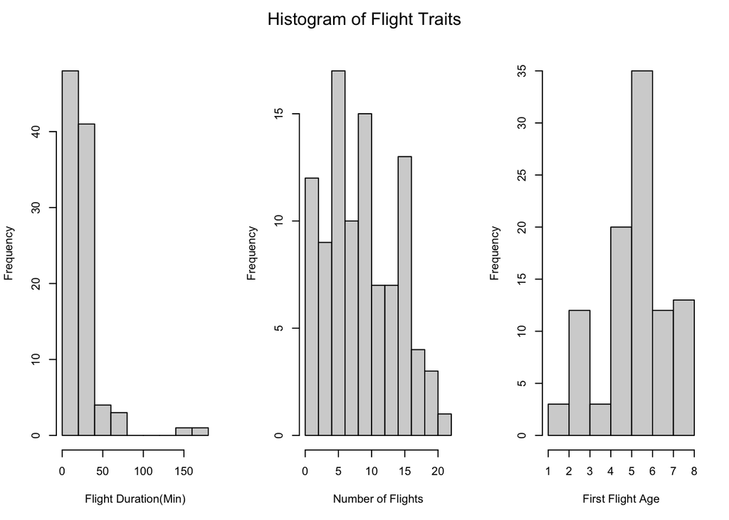

Flight traits for age 14

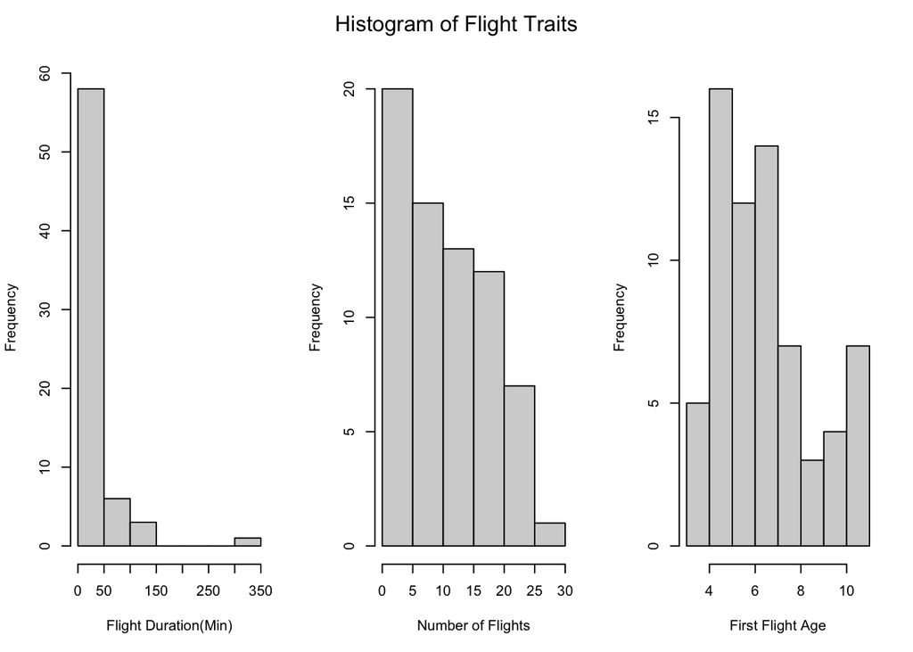

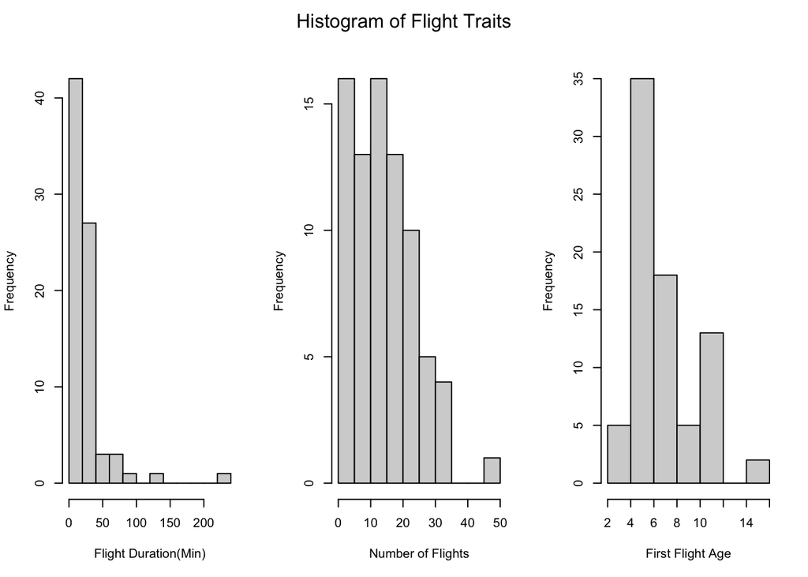

## Sperm Traits

Sperm Traits Regardless of age

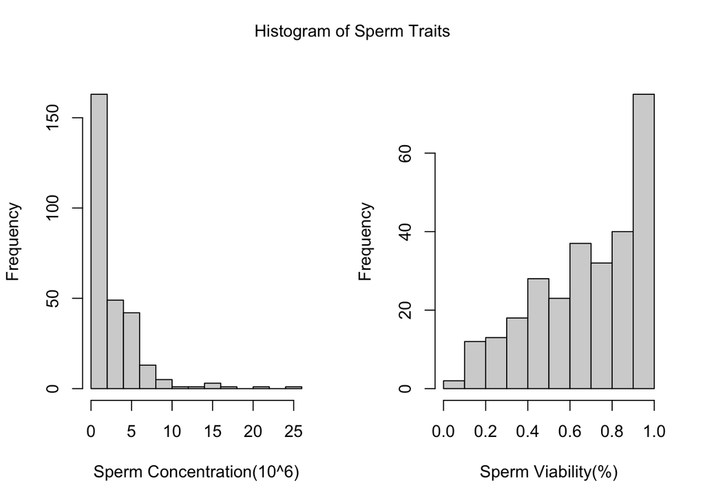

Sperm Traits Age 10

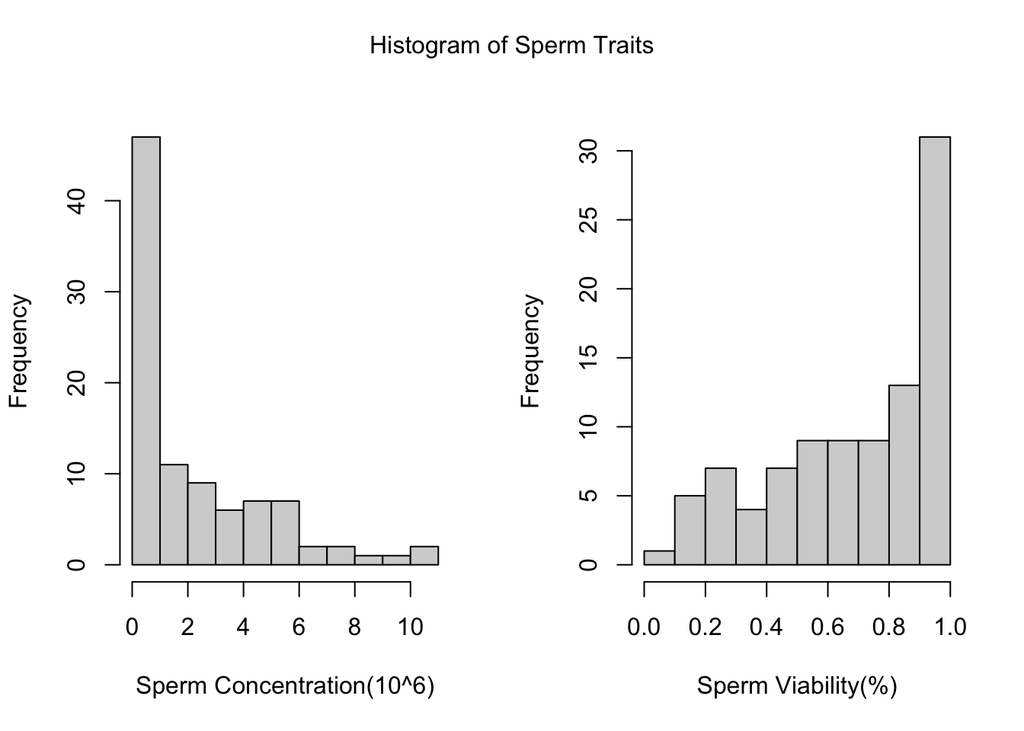

Sperm Traits Age 14

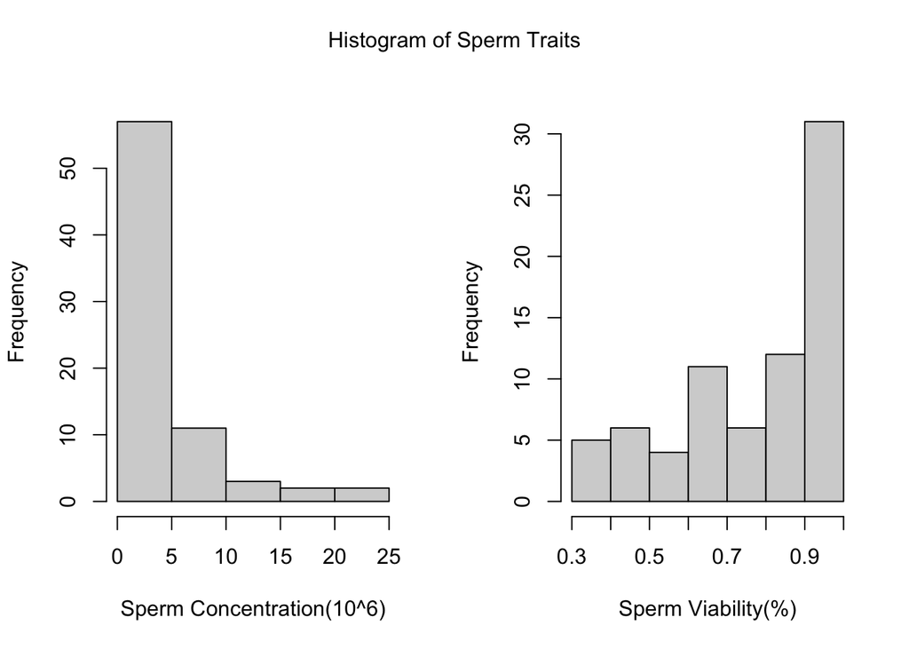

Sperm Traits Age 20

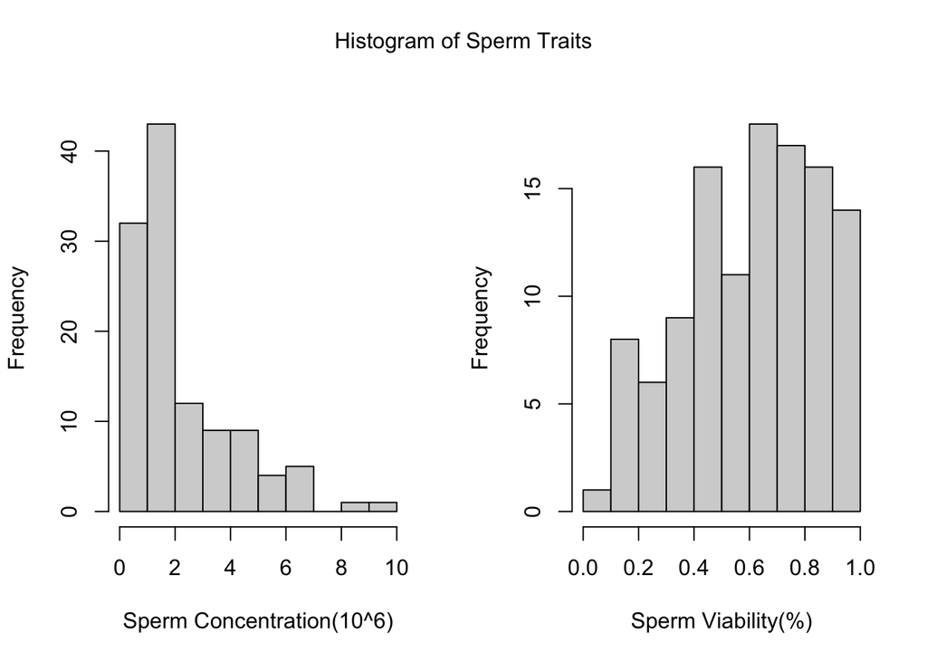

## Morphology Traits

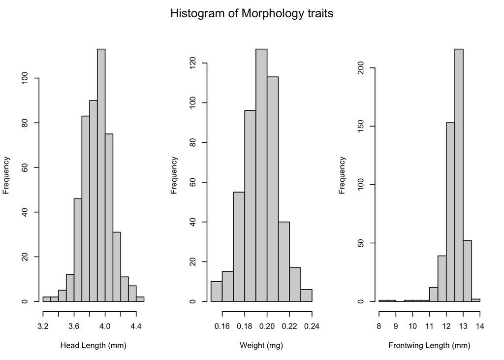

# 2. Generate trait means

## Sperm Traits - By Line

Sperm Traits regardless of age (Mean)

```
# A tibble: 4 × 3
  Line    Sperm_Concentration Sperm_Viability
  <chr>                 <dbl>           <dbl>
1 CA                     3.36           0.713
2 Purdue                 2.44           0.666
3 Russian                2.05           0.627
4 Texas                  2.21           0.676
```

Sperm Traits with age (Mean)

```
# A tibble: 12 × 4
# Groups:   Line [4]
   Line      Age Sperm_Concentration Sperm_Viability
   <chr>   <dbl>               <dbl>           <dbl>
 1 CA         10                2.89           0.767
 2 CA         14                6.19           0.818
 3 CA         20                2.16           0.621
 4 Purdue     10                1.88           0.641
 5 Purdue     14                2.55           0.703
 6 Purdue     20                3.51           0.673
 7 Russian    10                1.42           0.542
 8 Russian    14                2.86           0.780
 9 Russian    20                1.82           0.570
10 Texas      10                2.31           0.715
11 Texas      14                2.11           0.698
12 Texas      20                2.16           0.622
```

## Sperm Traits - By Colony

Sperm Traits regardless of age

```
# A tibble: 19 × 3
   Colony  Sperm_Concentration Sperm_Viability
   <chr>                 <dbl>           <dbl>
 1 CAC2002               3.25            0.747
 2 CAC2007               2.30            0.679
 3 CAC2008               2.50            0.696
 4 CAI2003               0.854           0.595
 5 CAI2004               7.63            0.876
 6 CAI2005               2.10            0.591
 7 CAI2007              14.3             0.988
 8 CAI2009               3.26            0.706
 9 P2001                 2.78            0.652
10 P2003                 1.18            0.621
11 P2004                 1.75            0.712
12 P2005                 3.15            0.663
13 R1308-2               1.69            0.487
14 R2003                 2.19            0.644
15 R2005                 1.95            0.659
16 T1104                 0.781           0.488
17 TX1104                1.97            0.715
18 TX2001                2.79            0.630
19 TX2003                2.20            0.718
```

Sperm Traits with age

```
# A tibble: 46 × 4
# Groups:   Colony [19]
   Colony    Age Sperm_Concentration Sperm_Viability
   <chr>   <dbl>               <dbl>           <dbl>
 1 CAC2002    10               3.12            0.820
 2 CAC2002    14               5.84            0.921
 3 CAC2002    20               2.40            0.637
 4 CAC2007    10               2.40            0.711
 5 CAC2007    14               2.17            0.633
 6 CAC2008    10               2.70            0.737
 7 CAC2008    14               2.33            0.754
 8 CAC2008    20               2.45            0.664
 9 CAI2003    10               1.02            0.803
10 CAI2003    14               0.773           0.490
# … with 36 more rows
```

## Flight Traits - By Line

Flight Traits regardless of age (Mean)

```
# A tibble: 4 × 4
  Line    mean_flight_timediff first_flight_age N_flights
  <chr>                  <dbl>            <dbl>     <dbl>
1 CA                      25.5             6.73      17.0
2 Purdue                  46.7             7.43      12.3
3 Russian                 24.8             9         11.8
4 Texas                   27.1             6.54      13.4
```

```
# A tibble: 4 × 5
# Groups:   Line [4]
  Line    phen_age mean_flight_timediff first_flight_age N_flights
  <chr>      <dbl>                <dbl>            <dbl>     <dbl>
1 CA            20                 25.5             6.73      17.0
2 Purdue        20                 46.7             7.43      12.3
3 Russian       20                 24.8             9         11.8
4 Texas         20                 27.1             6.54      13.4
```

## Flight Traits - By Colony

Flight Traits regardless of age (Mean)

```
# A tibble: 14 × 4
   Colony  mean_flight_timediff first_flight_age N_flights
   <chr>                  <dbl>            <dbl>     <dbl>
 1 CAC2002                 20.8             6.53     17.5
 2 CAC2007                 11.5             5         1
 3 CAC2008                 30.4             7.91     15.6
 4 CAI2003                 23.9            12        13
 5 CAI2004                 25.7             3        25
 6 CAI2005                 27.5             5.67     21.5
 7 CAI2009                 35.2             5        14
 8 P2001                   24.3             6        13.5
 9 P2005                   55.7             8        11.8
10 R1308-2                 23.5             5        28
11 R2003                   27.1            10.5       7.57
12 R2005                   19.8             6.17     18.8
13 TX1104                  26.5             6.33     10.7
14 TX2001                  27.6             6.71     15.7
```

```
# A tibble: 14 × 5
# Groups:   Colony [14]
   Colony  phen_age mean_flight_timediff first_flight_age N_flights
   <chr>      <dbl>                <dbl>            <dbl>     <dbl>
 1 CAC2002       20                 20.8             6.53     17.5
 2 CAC2007       20                 11.5             5         1
 3 CAC2008       20                 30.4             7.91     15.6
 4 CAI2003       20                 23.9            12        13
 5 CAI2004       20                 25.7             3        25
 6 CAI2005       20                 27.5             5.67     21.5
 7 CAI2009       20                 35.2             5        14
 8 P2001         20                 24.3             6        13.5
 9 P2005         20                 55.7             8        11.8
10 R1308-2       20                 23.5             5        28
11 R2003         20                 27.1            10.5       7.57
12 R2005         20                 19.8             6.17     18.8
13 TX1104        20                 26.5             6.33     10.7
14 TX2001        20                 27.6             6.71     15.7
```

## Morphology Traits - Line

```
# A tibble: 4 × 4
  Line    Weight head_length frontwing_length
  <chr>    <dbl>       <dbl>            <dbl>
1 CA       0.200        3.89             12.5
2 Purdue   0.204        3.88             12.5
3 Russian  0.197        3.93             12.6
4 Texas    0.196        3.88             12.4
```

## Morphology Traits - Colony

```
# A tibble: 20 × 4
   Colony  Weight head_length frontwing_length
   <chr>    <dbl>       <dbl>            <dbl>
 1 CAC2002  0.196        3.82             12.5
 2 CAC2007  0.189        3.88             11.9
 3 CAC2008  0.208        3.93             12.8
 4 CAI2003  0.186        3.78             12.5
 5 CAI2004  0.207        3.93             12.5
 6 CAI2005  0.201        3.94             12.7
 7 CAI2007  0.18         3.60             12.0
 8 CAI2009  0.199        3.89             12.3
 9 P2001    0.199        3.90             12.2
10 P2003    0.207        3.77             12.5
11 P2004    0.216        3.97             12.8
12 P2005    0.199        3.91             12.6
13 R1308-2  0.190        3.86             12.4
14 R2003    0.198        3.94             12.6
15 R2005    0.201        3.98             12.6
16 T1104    0.207        3.85             12.4
17 T2001    0.19         3.57             12.6
18 TX1104   0.194        3.85             12.3
19 TX2001   0.197        3.92             12.5
20 TX2003   0.194        3.88             12.5
```

# 3. LMER Variation

For non-repeated traits (measured once per drone’s life) - I assume that you have traits measured at different ages so I am leaving in the model the factor effect of age - if this is not true, then remove age - pick one focal trait here so we work out the pipeline and then you can repeat it for other such traits:

## Sperm Traits

### Sperm Concentration

```
Linear mixed model fit by REML ['lmerMod']
Formula: Sperm_Conc_2 ~ Age + Line + (1 | Colony)
   Data: Sperm_1
REML criterion at convergence: 1415.19
Random effects:
 Groups   Name        Std.Dev.
 Colony   (Intercept) 1.378
 Residual             2.928
Number of obs: 280, groups:  Colony, 19
Fixed Effects:
(Intercept)          Age   LinePurdue  LineRussian    LineTexas
    3.90813     -0.01778     -1.37867     -1.66674     -1.54129
```

### Sperm Viability

```
Linear mixed model fit by REML ['lmerMod']
Formula: Sperm_viability ~ Age + Line + (1 | Colony)
   Data: Sperm_1
REML criterion at convergence: 23.0331
Random effects:
 Groups   Name        Std.Dev.
 Colony   (Intercept) 0.003383
 Residual             0.241062
Number of obs: 280, groups:  Colony, 19
Fixed Effects:
(Intercept)          Age   LinePurdue  LineRussian    LineTexas
   0.867714    -0.009968    -0.068021    -0.081877    -0.045121
```

## Flight Traits

Flight Duration

```
Linear mixed model fit by REML ['lmerMod']
Formula: mean_flight_timediff ~ phen_age + Line + (1 | Colony)
   Data: flight_1
REML criterion at convergence: 725.9114
Random effects:
 Groups   Name        Std.Dev.
 Colony   (Intercept)  0.00
 Residual             30.28
Number of obs: 78, groups:  Colony, 14
Fixed Effects:
(Intercept)   LinePurdue  LineRussian    LineTexas
     25.485       21.253       -0.649        1.586
fit warnings:
fixed-effect model matrix is rank deficient so dropping 1 column / coefficient
optimizer (nloptwrap) convergence code: 0 (OK) ; 0 optimizer warnings; 1 lme4 warnings
```

### Number of Flights per day

```
Linear mixed model fit by REML ['lmerMod']
Formula: N_flights ~ phen_age + Line + (1 | Colony)
   Data: flight_1
REML criterion at convergence: 555.5248
Random effects:
 Groups   Name        Std.Dev.
 Colony   (Intercept) 3.350
 Residual             9.307
Number of obs: 78, groups:  Colony, 14
Fixed Effects:
(Intercept)   LinePurdue  LineRussian    LineTexas
     16.768       -4.384       -3.122       -3.472
fit warnings:
fixed-effect model matrix is rank deficient so dropping 1 column / coefficient
```

### First Flight Age

```
Linear mixed model fit by REML ['lmerMod']
Formula: first_flight_age ~ phen_age + Line + (1 | Colony)
   Data: flight_1
REML criterion at convergence: 357.0582
Random effects:
 Groups   Name        Std.Dev.
 Colony   (Intercept) 1.633
 Residual             2.339
Number of obs: 78, groups:  Colony, 14
Fixed Effects:
(Intercept)   LinePurdue  LineRussian    LineTexas
    6.50492      0.67424      1.40841      0.02242
fit warnings:
fixed-effect model matrix is rank deficient so dropping 1 column / coefficient
```

# 5. MCM Variation

# Pedigree

```
Assuming male heterogametic (e.g., XX/XY) sex chromosome system
S-inverse made: Starting to make S....done
```

# GLMM

### Sperm Concentration

[output not shown]

[output cut: 348 more lines]

[output not shown]

```
 Iterations = 10001:99991
 Thinning interval  = 10
 Sample size  = 9000

 DIC: 1149.044

 G-structure:  ~animal

       post.mean  l-95% CI u-95% CI eff.samp
animal   0.06843 4.141e-09   0.2168     1307

               ~Dom

    post.mean  l-95% CI u-95% CI eff.samp
Dom    0.1397 2.158e-11   0.4244     1764

 R-structure:  ~units

      post.mean l-95% CI u-95% CI eff.samp
units      0.25   0.1065   0.3855     1839

 Location effects: Sperm_Conc_3 ~ Age + Line

            post.mean  l-95% CI  u-95% CI eff.samp  pMCMC
(Intercept)  1.211344  0.784349  1.653283     7501 <1e-04 ***
Age         -0.004274 -0.028956  0.019511     6544 0.7320
LinePurdue  -0.289020 -0.698198  0.124789     7065 0.1576
LineRussian -0.372939 -0.778179  0.064365     7391 0.0769 .
LineTexas   -0.315680 -0.736794  0.138909     7326 0.1511
---
Signif. codes:  0 '***' 0.001 '**' 0.01 '*' 0.05 '.' 0.1 ' ' 1
```

```
[1] 0.07397469
```

```
            lower     upper
var1 4.557829e-09 0.2360889
attr(,"Probability")
[1] 0.95
```

### Sperm Viability

[output not shown]

[output cut: 348 more lines]

[output not shown]

```
 Iterations = 10001:99991
 Thinning interval  = 10
 Sample size  = 9000

 DIC: 2231.89

 G-structure:  ~animal

       post.mean  l-95% CI u-95% CI eff.samp
animal   0.01693 8.508e-12  0.05957     3289

               ~Dom

    post.mean  l-95% CI u-95% CI eff.samp
Dom   0.02254 6.422e-10  0.08579     4041

 R-structure:  ~units

      post.mean l-95% CI u-95% CI eff.samp
units    0.1746   0.1222   0.2219     4730

 Location effects: Sperm_viability ~ Age + Line

            post.mean  l-95% CI  u-95% CI eff.samp  pMCMC
(Intercept)  4.418336  4.182121  4.651570     9000 <1e-04 ***
Age         -0.014355 -0.027204 -0.000633     9000 0.0324 *
LinePurdue  -0.091075 -0.298121  0.104552     8617 0.3553
LineRussian -0.169079 -0.381517  0.018542     8549 0.0929 .
LineTexas   -0.062878 -0.271848  0.160011     8634 0.5500
---
Signif. codes:  0 '***' 0.001 '**' 0.01 '*' 0.05 '.' 0.1 ' ' 1
```

```
[1] 0.06214152
```

```
           lower     upper
var1 3.75962e-11 0.2142616
attr(,"Probability")
[1] 0.95
```

## Flight Traits

Flight Duration

[output not shown]

[output cut: 348 more lines]

[output not shown]

```
 Iterations = 10001:99991
 Thinning interval  = 10
 Sample size  = 9000

 DIC: 1670.58

 G-structure:  ~animal

       post.mean  l-95% CI u-95% CI eff.samp
animal   0.04119 1.738e-09   0.1533     2390

               ~Dom

    post.mean  l-95% CI u-95% CI eff.samp
Dom   0.04199 6.251e-09   0.1641     5365

 R-structure:  ~units

      post.mean l-95% CI u-95% CI eff.samp
units     0.402   0.2779   0.5351     3541

 Location effects: mean_flight_timediff ~ phen_age + Line

            post.mean  l-95% CI  u-95% CI eff.samp  pMCMC
(Intercept)  2.970141  2.603295  3.342397     9425 <1e-04 ***
phen_age     0.006529 -0.015702  0.028013     9000  0.570
LinePurdue   0.232864 -0.081647  0.562782     9000  0.156
LineRussian  0.017845 -0.291168  0.327554     9290  0.898
LineTexas    0.072110 -0.226648  0.397270     8842  0.622
---
Signif. codes:  0 '***' 0.001 '**' 0.01 '*' 0.05 '.' 0.1 ' ' 1
```

```
[1] 0.05743208
```

```
           lower     upper
var1 2.81127e-09 0.2099756
attr(,"Probability")
[1] 0.95
```

### Number of Flights per day

[output not shown]

[output cut: 348 more lines]

[output not shown]

```
 Iterations = 10001:99991
 Thinning interval  = 10
 Sample size  = 9000

 DIC: 1427.474

 G-structure:  ~animal

       post.mean  l-95% CI u-95% CI eff.samp
animal    0.1019 1.635e-10   0.2826     1172

               ~Dom

    post.mean  l-95% CI u-95% CI eff.samp
Dom     0.226 2.098e-08   0.5839     1616

 R-structure:  ~units

      post.mean l-95% CI u-95% CI eff.samp
units    0.2473    0.111   0.3872     2466

 Location effects: N_flights ~ phen_age + Line

            post.mean l-95% CI u-95% CI eff.samp  pMCMC
(Intercept)   1.61860  1.20307  2.05657     8496 <1e-04 ***
phen_age      0.04991  0.02683  0.07249     8537 <1e-04 ***
LinePurdue    0.01677 -0.46497  0.45111     8059  0.928
LineRussian  -0.16660 -0.61669  0.29006     9000  0.452
LineTexas    -0.20976 -0.63651  0.24345     9000  0.344
---
Signif. codes:  0 '***' 0.001 '**' 0.01 '*' 0.05 '.' 0.1 ' ' 1
```

```
[1] 0.1137322
```

```
            lower     upper
var1 1.427994e-10 0.3331311
attr(,"Probability")
[1] 0.95
```

### First Flight Age

[output not shown]

[output cut: 348 more lines]

[output not shown]

```
 Iterations = 10001:99991
 Thinning interval  = 10
 Sample size  = 9000

 DIC: 1109.592

 G-structure:  ~animal

       post.mean  l-95% CI u-95% CI eff.samp
animal  0.003326 4.587e-13  0.01256     4096

               ~Dom

    post.mean  l-95% CI u-95% CI eff.samp
Dom   0.01925 8.239e-09  0.04994     2331

 R-structure:  ~units

      post.mean l-95% CI u-95% CI eff.samp
units   0.04048  0.02545   0.0572     4101

 Location effects: first_flight_age ~ phen_age + Line

            post.mean  l-95% CI  u-95% CI eff.samp   pMCMC
(Intercept)  1.534462  1.303485  1.773382     3795 < 1e-04 ***
phen_age     0.021138  0.007537  0.035513     3779 0.00333 **
LinePurdue  -0.150360 -0.355783  0.059618     3746 0.15711
LineRussian  0.091783 -0.087341  0.275967     4156 0.30867
LineTexas    0.004492 -0.183692  0.186267     4270 0.96467
---
Signif. codes:  0 '***' 0.001 '**' 0.01 '*' 0.05 '.' 0.1 ' ' 1
```

```
[1] 0.01390489
```

```
            lower      upper
var1 1.913361e-12 0.05221741
attr(,"Probability")
[1] 0.95
```

## Morphology

### Weight

[output not shown]

[output cut: 146 more lines]

[output not shown]

```
 Iterations = 10001:99991
 Thinning interval  = 10
 Sample size  = 9000

 DIC: -2807.448

 G-structure:  ~animal

       post.mean  l-95% CI  u-95% CI eff.samp
animal  0.000113 7.059e-05 0.0001544     3351

               ~Dom

    post.mean  l-95% CI  u-95% CI eff.samp
Dom 0.0001806 9.388e-05 0.0002738     2458

 R-structure:  ~units

      post.mean  l-95% CI  u-95% CI eff.samp
units 0.0001036 7.016e-05 0.0001377     4268

 Location effects: Weight ~ phen_age + Line

             post.mean   l-95% CI   u-95% CI eff.samp  pMCMC
(Intercept)  2.027e-01  1.941e-01  2.112e-01     9286 <1e-04 ***
phen_age    -3.256e-04 -6.667e-04  3.702e-05     9371 0.0698 .
LinePurdue   7.385e-03 -3.742e-03  1.876e-02     9000 0.1893
LineRussian -1.366e-03 -1.382e-02  1.043e-02     8925 0.8253
LineTexas   -1.987e-03 -1.337e-02  9.184e-03     9000 0.7360
---
Signif. codes:  0 '***' 0.001 '**' 0.01 '*' 0.05 '.' 0.1 ' ' 1
```

```
[1] 0.0003972565
```

```
[1] 0.0004265854
```

```
[1] 0.2677997
```

```
         lower     upper
var1 0.1615791 0.3825188
attr(,"Probability")
[1] 0.95
```

### basitarsus length

[output not shown]

[output cut: 146 more lines]

[output not shown]

```
 Iterations = 10001:99991
 Thinning interval  = 10
 Sample size  = 9000

 DIC: -2014.735

 G-structure:  ~animal

       post.mean l-95% CI u-95% CI eff.samp
animal   0.02847  0.01466  0.03684    121.9

               ~Dom

    post.mean  l-95% CI u-95% CI eff.samp
Dom   0.01038 0.0001537  0.04208    136.4

 R-structure:  ~units

      post.mean  l-95% CI u-95% CI eff.samp
units 0.0009238 9.136e-05 0.002729    136.3

 Location effects: basitarsus_length ~ phen_age + Line

             post.mean   l-95% CI   u-95% CI eff.samp  pMCMC
(Intercept)  2.6091068  2.5131530  2.7007760     9000 <1e-04 ***
phen_age     0.0001969 -0.0033917  0.0039489     9000  0.915
LinePurdue  -0.0036446 -0.1290023  0.1238731     9000  0.949
LineRussian -0.0641574 -0.2068110  0.0753297     9000  0.366
LineTexas   -0.0449505 -0.1714192  0.0845516     9000  0.481
---
Signif. codes:  0 '***' 0.001 '**' 0.01 '*' 0.05 '.' 0.1 ' ' 1
```

```
[1] 0.03977426
```

```
[1] 0.04242278
```

```
[1] 0.7165081
```

```
         lower     upper
var1 0.2510393 0.9672703
attr(,"Probability")
[1] 0.95
```

[output not shown]

[output cut: 146 more lines]

[output not shown]

```
 Iterations = 10001:99991
 Thinning interval  = 10
 Sample size  = 9000

 DIC: -1964.696

 G-structure:  ~animal

       post.mean l-95% CI u-95% CI eff.samp
animal   0.07821  0.06018   0.0958    227.4

               ~Dom

    post.mean  l-95% CI u-95% CI eff.samp
Dom   0.01575 0.0002192  0.06055    126.7

 R-structure:  ~units

      post.mean  l-95% CI u-95% CI eff.samp
units 0.0006901 9.596e-05 0.002005    307.6

 Location effects: frontwing_width ~ phen_age + Line

            post.mean  l-95% CI  u-95% CI eff.samp  pMCMC
(Intercept)  3.903498  3.755236  4.050211     9000 <1e-04 ***
phen_age     0.002468 -0.003366  0.008215     9000  0.404
LinePurdue  -0.098221 -0.304706  0.098128     9000  0.337
LineRussian -0.060434 -0.276128  0.155478     9000  0.579
LineTexas   -0.078981 -0.272429  0.126087     9000  0.428
---
Signif. codes:  0 '***' 0.001 '**' 0.01 '*' 0.05 '.' 0.1 ' ' 1
```

```
[1] 0.09464983
```

```
[1] 0.1011236
```

```
[1] 0.8004696
```

```
         lower     upper
var1 0.4732575 0.9834493
attr(,"Probability")
[1] 0.95
```

### Maturity

[output not shown]

[output cut: 146 more lines]

[output not shown]

```
 Iterations = 10001:99991
 Thinning interval  = 10
 Sample size  = 9000

 DIC: -87.52845

 G-structure:  ~animal

       post.mean l-95% CI  u-95% CI eff.samp
animal 1.183e+11    48.36 7.092e+11    20.35

               ~Dom

    post.mean  l-95% CI u-95% CI eff.samp
Dom    629909 0.0002222   861640    118.3

 R-structure:  ~units

      post.mean l-95% CI  u-95% CI eff.samp
units 1.581e+10 0.000189 4.382e+10    111.3

 Location effects: Maturity ~ phen_age + Line

            post.mean  l-95% CI  u-95% CI eff.samp pMCMC
(Intercept)  -13213.0 -165013.3   21106.8    44.59 0.127
phen_age       -430.8   -9837.1    5876.2   227.76 0.564
LinePurdue     1623.8  -96408.8  105540.4  3079.90 0.506
LineRussian   -4004.2 -113706.5   85432.4  1054.83 0.922
LineTexas      7341.2  -80455.7  114756.1   312.40 0.289
```

```
    var1
48.58525
```

```
[1] 0.9271707
```

```
         lower     upper
var1 0.5382341 0.9999995
attr(,"Probability")
[1] 0.95
```

```
[1] 0.5331278
```

```
         lower     upper
var1 0.3098943 0.6366188
attr(,"Probability")
[1] 0.95
```